Faculty of Economic Sciences

Advanced programming in R - Academic year 2020/2021

5. Introduction to R Markdown.

# 1. Document compilation and Markdown syntax

Piotr Ćwiakowski, Piotr Wójcik

25 marzec, 2021

According to wikipedia, Markdown *is a lightweight markup language with plain-text-formatting syntax. Its design allows it to be converted to many output formats, but the original tool by the same name only supports HTML.[9] Markdown is often used to format readme files, for writing messages in online discussion forums, and to create rich text using a plain text editor.*

R Markdown is therefore implementation of markdown technology in R environment. The integrention was conducted by R Studio in their IDE for R.

# 1. Creating new document

New R Markdown document can be created by choosing from menu File -> New File -> R Markdown…:

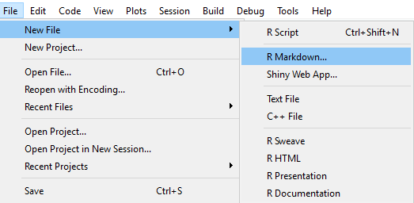

Afterwards, if we launch this option for the first time, some packages can be automatically installed. Then, in the next window, we can choose what kind of file (document/presentation/shiny app/template) we want to create and in what format (html, pdf, MS Office/Open Office). For purpose of this tutorial we will create html document. However after reading this materials we enhance you to try different options. On this webpage https://rmarkdown.rstudio.com/formats.html you can study options and difference of various formats.

[figure not shown]

After clicking “OK” button new script appeared in R Studio (with extention `.Rmd`), which works differently than oridnary `*.R` file:

[figure not shown]

If we carefully study this exemplary script we can distinct three different areas:

- header, delineated from the body of the script with three dashes `---`, it is configuration part written using *YAML* language - more about it is available [here](https://bookdown.org/yihui/rmarkdown/html-document.html),
- blocks of R codes, delineated with apostrophs, called *chunks* which generates output to the document - we will deal with them in second part of the materials,
- rest of the document, which consists mostly raw text - the description of the document/report/article, which can be formatted in Markdown - in the introductory part below *markdown syntax* is discussed.

For more profound discussion let’s see below materials available online:

- [Definitive guide of Markdown](https://bookdown.org/yihui/rmarkdown/)
- [Official R Markdown webpage](https://rmarkdown.rstudio.com/index.html)

# 2. Text formatting

Text of the document needs organisations (chapter, headlines, sections, paragraphs, etc.) and styling/formating (bold, italic etc.). In Markdown syntax most of the basic formating are available. Complete (all almost colmplete) list of operations (special symbols) are gathered in pdf cheasheets attached to this materials (`5_rmarkdown-2.0.pdf` and `5_rmarkdown-reference.pdf`). Below in tabset-like fashion we present most of them in examples. In tab `script.Rmd` you can found exemplary code written in R Markdown. On the other hand, tab `document.html` consists compiled code, therefore you can immedietely check out the effect of given markdown syntax.

## Font editions

### script.Rmd

`This is **bolded** text, and this is *italic*. Instead of stars one can use underscores: single to make _italic_ text and double for __bolding__. If you want to cross out text you need to use tilde: ~~przykład~~.`

`one and a half pause can be denoted by double dash: --, and double pause with triple dash: ---`

`If you want to use star or underscore as raw symbol, you need to precede it with backslash (as escape sign): \* albo \_.`

Text in R styling code can be denotef using apostrophs, e. g.: some `R code`.

### document.html

This is **bolded** text, and this is *italic*. Instead of stars one can use underscores: single to make *italic* text and double for **bolding**. If you want to cross out text you need to use tilde: przykład.

one and a half pause can be denoted by double dash: –, and double pause with triple dash: —

If you want to use star or underscore as raw symbol, you need to precede it with backslash (as escape sign): * albo _.

Text in R styling code can be denotef using apostrophs, e. g.: some `R code`.

## Headers

Header are created by preceding text with one or more `#`.

### script.Rmd

```
# 1. Header

## 1.1 Header

### 1.1.1 Header

#### 1.1.1.1 Header

##### 1.1.1.1.1 Header

###### 1.1.1.1.1.1 Header
```

### document.html

```
# 1. Header

## 1.1 Header

### 1.1.1 Header

#### 1.1.1.1 Header

##### 1.1.1.1.1 Header

###### 1.1.1.1.1.1 Header
```

## Superscripts and subscripts

### script.Rmd

superscript: `y<sup>1</sup>` or `y^1^`

subscript: `y<sub>1</sub>` or `y~1~`

### document.html

superscript: y<sup>1</sup> pr y<sup>1</sup>

subscript: y<sub>1</sub> or y<sub>1</sub>

## Paragraphs

If we want to separate part of the graphs by empty line, we cannot simply put it in separate lines. There are two options:

- double spaces - to put text in new line, but in the same paragraph,
- double EOL symbols (enters) - to create new paragrap. More EOL will be ignored.

Study the examples.

### script.Rmd

```
Text in first line.
Text in second line.


***
Text in first line.

Text in second line.


***
Text in first line.



Text in second line.

***
```

### document.html

Text in first line. Text in second line.

Text in first line.

Text in second line.

Text in first line.

Text in second line.

## Lists (ordered and unordered)

### script.Rmd

```
bullet list:

* item 1

or

- item 2

or

+ item 3

ordered list:

1. Item 1
    + subitem 1.1
    + subitem 1.2
2. Item 2
3. Item 3
4. Item 4
```

### document.html

bullet list:

- item 1

or

- item 2

or

- item 3

ordered list:

1. Item 1
   - subitem 1.1
   - subitem 1.2
2. Item 2
3. Item 3
4. Item 4

## Quotation

In order to create qoutation cited text should be preceded with `>`

### script.Rmd

```
> This is quotation

And then next paragraph
```

[output not shown]

### document.html

> This is qoutation.

And then next paragraph:

> Lorem ipsum dolor sit amet, consectetur adipiscing elit. Proin nibh augue, suscipit a, scelerisque sed, lacinia in, mi. Cras vel lorem. Etiam pellentesque aliquet tellus. Phasellus pharetra nulla ac diam. Quisque semper justo at risus. Donec venenatis, turpis vel hendrerit interdum, dui ligula ultricies purus, sed posuere libero dui id orci. Nam congue, pede vitae dapibus aliquet, elit magna vulputate arcu, vel tempus metus leo non est.

> Etiam sit amet lectus quis est congue mollis. Phasellus congue lacus eget neque. Phasellus ornare, ante vitae consectetuer consequat, purus sapien ultricies dolor, et mollis pede metus eget nisi. Praesent sodales velit quis augue. Cras suscipit, urna at aliquam rhoncus, urna quam viverra nisi, in interdum massa nibh nec erat.

## Math equations

In Markdown is implemented special syntax for equations, almost the same as in LaTeX and HTML (mathjax package). More information can be found below, however from our examples and google browser you can extract or necessary information.

- [official web page of mathjax package](https://www.mathjax.org/)
- [mathjax on wikipedia](https://en.wikipedia.org/wiki/MathJax)
- [Tutorial on Stack Exchange](https://math.meta.stackexchange.com/questions/5020/mathjax-basic-tutorial-and-quick-reference)

### script.Rmd

There are two ways of including equations in repotr, inline (single dollar signs): `$A = \pi*r^{2}$`, or as centered, separate sections (double dollar signs): `$$A = \pi*r^{2}$$`

````
$\alpha$ - ```$\alpha$```

$\beta$ -  ```$\beta$```

$\omega$ - ```$\omega$```

$\Gamma$ - ```$\Gamma$```

$\Delta$ - ```$\Delta$```

$x_i$ - ```$x_i$```

$x^2$ - ```$x^2$```

$\log_2$ - ```$\log_2 x$``

$\frac{x}{y}$ - ```$\frac{x}{y}$```

$\sum_1^n$ - ```$\sum_1^n$```

Few examples of equations:

$$\sum_{i=0}^n i^2 = \frac{(n^2+n)(2n+1)}{6}$$

$$\Biggl(\biggl(\Bigl(\bigl((x)\bigr)\Bigr)\biggr)\Biggr)$$
````

### document.html

In Markdown is implemented special syntax for equations, almost the same as in LaTeX and HTML (mathjax package). There are two ways of including equations in repotr, inline (single dollar signs): $A = \pi*r^{2}$, or as centered, separate sections (double dollar signs):
$$A = \pi*r^{2}$$

Selected examples:

$\alpha$ - `$\alpha$`

$\beta$ - `$\beta$`

$\omega$ - `$\omega$`

$\Gamma$ - `$\Gamma$`

$\Delta$ - `$\Delta$`

$x_i$ - `$x_i$`

$x^2$ - `$x^2$`

$\log_2$ - ``$\log_2 x$`

$\frac{x}{y}$ - `$\frac{x}{y}$`

$\sum_1^n$ - `$\sum_1^n$`

Few examples of equations:

$$\sum_{i=0}^n i^2 = \frac{(n^2+n)(2n+1)}{6}$$

$$\Biggl(\biggl(\Bigl(\bigl((x)\bigr)\Bigr)\biggr)\Biggr)$$

You can find more information [here](http://www.martinkeefe.com/math/mathjax3), and [here](http://meta.math.stackexchange.com/questions/5020/mathjax-basic-tutorial-and-quick-reference)

## Inserting links

Syntax for inserting links is very straightforward.

### script.Rmd

```
[Link label](http://www.wne.uw.edu.pl)
```

### document.html

[Link label](http://www.wne.uw.edu.pl)

## HTML syntax

If we use html output, we can use raw HTML code. It can radically expand possibilities of text formatting. Below a simple example from which you start on. More about html language can be found for example [here.](https://www.w3schools.com/html/)

### script.Rmd

```
<font color="red">Text sample.</font>
```

### document.html

Text sample.

In the same way, but in pdf format, LaTeX syntax can be used.

# 3. Tables in the report

Usually, tables in our reports will be a result of an output of R code. However sometimes we will want to hardcode some table in the text. In that moments special syntax for table can be useful.

## Example

With colon symbols one can manipulate text justifying:

### script.Rmd

```
| Right | Left | Centre  |  Default  |
|------:|:-----|:-------:|-----------|
| 12    | 12   | 12      | 12        |
| 123   | 123  | 123     | 123       |
| 1     | 1    | 1       | 1         |
```

### document.html

| Right | Left | Centre | Default |
| --- | --- | --- | --- |
| 12 | 12 | 12 | 12 |
| 123 | 123 | 123 | 123 |
| 1 | 1 | 1 | 1 |

# 4. Inserting images

#### Example

##### script.Rmd

```
![](5_WNE.png)

<img src="5_WNE.png">

<center><img src="5_WNE.png"></center>
```

# 5. Tabset panels

In html one can modify behave of headers, placing expression `{.tabset}` after the text of header. Belowed code:

```
#### Example 1 {.tabset}

##### Tab 1.1

Content of Tab 1

##### Tab 1.2

Content of Tab 2
```

results in :

#### Example 1

##### Tab 1.1

Content of Tab 1

##### Tab 1.2

Content of Tab 2

This `{.tabset}` style have some additional options, which modify behavior and appearence of the tabsets. For example, `.tabset-fade` causes fading of the content, for example:

```
#### Example 2 {.tabset .tabset-fade}

##### Tab 2.1

Content of Tab 1

##### Tab 2.2

Content of Tab 2
```

#### Example 2

##### Tab 2.1

Content of Tab 1

##### Tab 2.2

Content of Tab 2

Option .tabset-pills change style of tabs.

```
#### Example 3 {.tabset .tabset-fade .tabset-pills}

##### Tab 3.1

Content of Tab 1

##### Tab 3.2

Content of Tab 2

####

If we want to finish tab section, we need to just put one hash symbol without any text after (otherwise this will be visible header)  and add paramwters: {.unlisted .unnumbered}
```

#### Example 3

##### Tab 3.1

Content of Tab 1

##### Tab 3.2

Content of Tab 2

If we want to finish tab section, we need to just put one hash symbol without any text after (otherwise this will be visible header) and add paramwters: {.unlisted .unnumbered}

# 6. Creating footnotes

#### Example

In Markdown there is special syntax for footnotes. Examlpe is below. Attention! One line space is important to make it works.

##### script.Rmd

```
This code generate footnote index in text [^1]

[^1]: And this is content of footnote in footer.
```

##### document.html

This code generate footnote index in text [^1]

# 7. Exercise (NOT homework, just to practice)

Pick one of wikipedia pages and use content on that page to create exemplary document file. you can use for example:

- https://en.wikipedia.org/wiki/Machine_learning
- https://en.wikipedia.org/wiki/Marvel_Cinematic_Universe
- https://en.wikipedia.org/wiki/History_of_Poland
[^1]: And this is content of footnote in footer.